# Your Digest for Friday, Oct 27, 2023 11:59 PM

- A transient loss of all spinal cord activity below a spinal cord insult including flaccid paralysis, paraesthesia, loss of bladder and bowel control, loss of reflexes, priapism in males, bradycardia and hypotension.
- Lasts around 2 weeks.
- Possible mechanisms: Increased intra spinal cord pottassium levels;
- release from descending tract inhibition of *inhibitory neurons* -> leading to inhibition of motor neurons;
- Denervation hypersensitivity plays a role in recovery.

## Mass reflex

Occurs in quadriplegic patients.  
There is extreme lowering of the threshold for the withdrawal reflex. Minor stimuli can trigger disproportionate reactions like prolonged withdrawal and even flexion-extension patterns in the *other limbs*; Aberrant reinnervation followings spinal cord injury can cause minor stimuli to cause autonomic dysregulation (hypotension, pallor, sweating) and bladder / bowel incontinence.

# Congenital adrenal hyperplasia

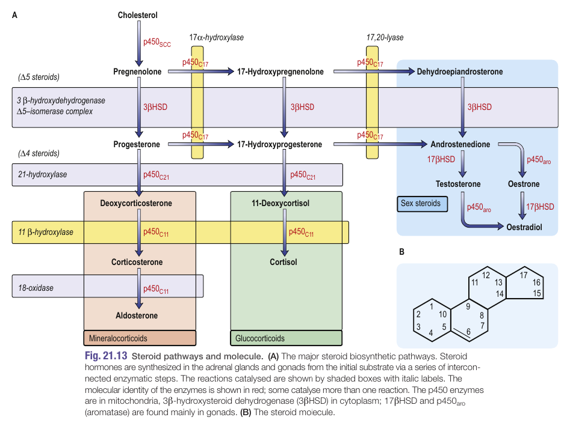

Congenital adrenal hyperplasia results from #autosomal-Recessive deficiency of **21-alpha hydroxylase enzyme**. Deficiency diverts synthesis towards the androgenic pathway and decreases mineralocorticoid and glucocorticoid function.

- increased testoterone -> virilization
- Inhibition of negative feedback of ACTH results in adrenal hyperplasia.
- Impaired aldosterone -> salt wasting.  
  Other forms of CAH: 11-beta hydroxylase deff, 17-alpha hydroxylase deff and 3-beta hydroxysteroid dehydrogenase deff.

Presentation is at birth

- females -> ambiguous genitalia
- Males -> salt wasting crisis will be the presenting feature at < 10 days old.

**Investigation**: *elevated 17OHP levels*.

# Complications of diabetes melitus

| microvascular complications | macrovascular complications |
| --- | --- |
| **Occular effects** | Atherosclerotic vascular disease |
| Diabetic retinopathy | ❗Heart failure❗(not due to IHD) |
| Cataract |  |
| Refractory defect |  |
| External ocular palsies |  |
| Glaucoma |  |
| Blindness |  |
| - |  |
| **Renal effects** |  |
| Diabetic nephropathy |  |
| Ischemic renal lesions |  |
| UTI |  |
| - |  |
| **Diabetic neuropathy** |  |

## Manifestations of diabetic neuropathy

### pathogenesis

- Mononeuritis is probably cause by ischemia of the vaso vasorum.
- Diffuse neuropathy is probably caused by increased sorbitol and fructose in the Schwann cells.
- **Early stages** -> **demyelination** -> causing decreased conduction velocity (even in the early stages) (demyelination may be reversible)
- **Progressive disease** causes **irreversible** axonal damage.

## Symmetrical distal polyneuropathy

1. *Earliest is loss of vibration sense and pain (deep before superficial) and temperature*
2. Later - loss of proprioception.
3. Interosseous wasting of foot muscles due to neuropathy of **motor nerves**.
   1. High Arched food with clawing of the toes
   2. Small muscle wasting is **also seen in the hands**
   3. **Carpal tunnel syndreme** is more common in DM

## Acute painful neuropathy

1. *Burning or crawling* pain in the feet, shins or thighs, *worse at night.*
2. Can present with *IMPROVEMENT* of glycaemic control but remits with continue glycaemic control
3. Treatment: Duloxetine, TCAs, gabapentin and pregabalin are first line agents have moderate effects.

## Mononeuritis and mononeuritis multiplex

- Sudden painless palsy of *any* nerve.
- However, most commonly affects CN 3 and CN 6;
- CN 3 lesions *spare the pupillary reflexes*.
- Spinal *nerve roots can be affected*.
- Resolution occurs over a few months.

## Diabetic amyotrophy

- *Asymmetrical Pain and weakness of the proximal leg muscles*
- Painful and tender wasting of the quadriceps muscles seen in older men with DM.
- Usually asymmetrical.
- Weakened / absent knee reflexes.
- But also Extensor plantar responses +
- CSF protein is elevated.
- Also called lumbosacral radiculoplexus neuropathy (LRPN)
- Pathophysiology : The most likely cause is ischemic injury from a nonsystemic microvasculitis.

## Autonomic neuropathy

Usually asymptomatic but can cause significant postural hypotension.

- Cardiovascular - loss of sinus arrhythmia, tachycardia, loss of valsalva reflex, 'denervated heart' in extreme cases
- Gastrointestinal : vagal damage -> intractable vomiting;
  - Also *dysphagia*, *constipation*, **diarrhoea** (*particularly at night*), faecal incontinence.
  - Bacterial overgrowth in small intesting -> bile salt deconjugation, malabsorption, diarrhoea, also *anaemia and macrocytosis*
- Urinary: Atonic, painless distended bladder.
- Sexual dysfunction: Occurs in *MEN and WOMEN*
  - Men: Incomplete erection -> erectile failure + *retrograde ejaculation*.
    - Due to inadequate vascular supply, concurrent use of thiazides and beta blockers, excess alcohol

Can be precipitated by anaesthetic drugs and luteal phase of the menstrual cycle.

# Anatomy of L4/L5 disk prolapse

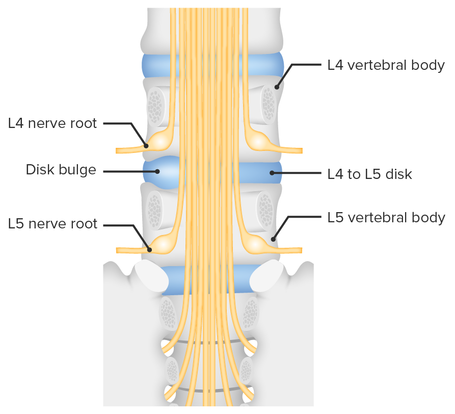

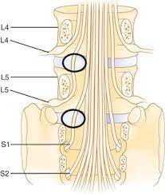

[Source](https://www.lecturio.com/concepts/spinal-disk-herniation/)

> The most prominent findings are **hyponatremia**, **hyperkalemia**, and a **mild non–anion-gap metabolic acidosis** due to the loss of the (sodium-retaining and potassium and hydrogen ion-secreting) action of aldosterone - [Source](https://emedicine.medscape.com/article/116467-workup)  
> [!TIP] Mnemonic  
> Mnemonic: *Addisonian acidosis*
- *Hypercalcemia* also occurs : cause is not known.
1. **Deficient mineralocorticoids** : (mineralocorticoid production may be preserved in some causes of adrenal dysfunction)  
   ?Deficiency H+ secretion -> acidosis
2. **Deficient glucocorticoids** : hypoglycaemia
- predominant symptom is **shock** + constituional symptoms - fatigue, lethargy, N/V, abdominal pain.

> Patients with chronic *primary* adrenal insufficiency -> symptoms and signs of *(1) glucocorticoid, (2)mineralocorticoid, and, **in women**, (3)androgen deficiency*.  
> In contrast, patients with **secondary or tertiary** adrenal insufficiency usually have **normal mineralocorticoid** function which is mainly stimulated by the RAAS system. Adrenal sex steroid production is also independent of pituitary action.

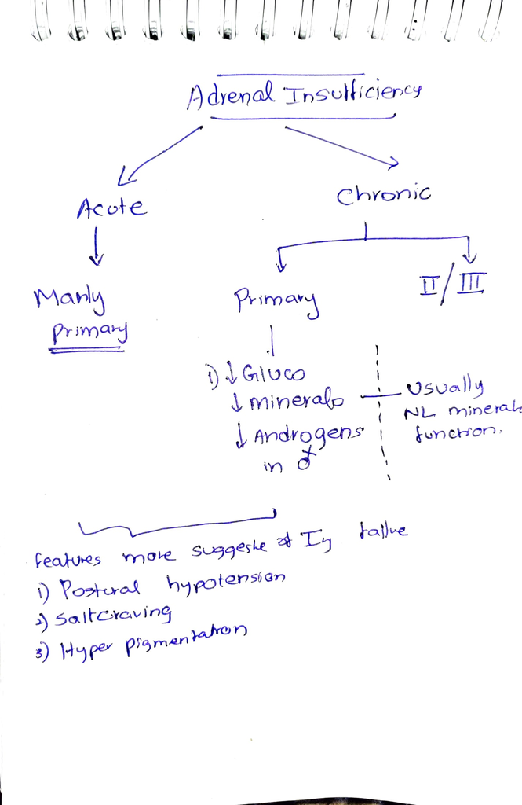

## Causes of primary adrenal insufficiency

- Autoimmune disease : commoner in women
- Tuberculosis
- rarer causes: meningogoccal septicaemia -> adrenal haemorrhage; Infiltration with malignancy or amyloid.

## 📑 Management of Addisonian crisis

- Management of addisonial crisis: 1 L within 30 to 60 minutes and large volume replacement over the next 24 hours.
- *intramuscular hydrocortison* 100mg 6 hourly

#### Mechanism of hypotension in adrenal crisis

- Salt wasting and dehydration
- Glucocorticoids deficiency causes hypotension by impaired vascular responsiveness to angiotensin II and norepinephrine, ↑ prostacyclin production and ↓ renin substrate (?angiotensinogen) production.

📑Activated vitamin D (1,25 dihydroxyvitamin D) regulates gene transcription by binding to intracellular receptors.  
Mechanism: dihydroxycholecalciferol binds to it's receptor (?nuclear receptor) and acts as a transcription regulator which increases **calbindin D** proteins.

**This protein increases intestinal calcium absorption.**  
Induction of another protein in the **renal tubules** increases renal calcium absorption.

> - a lesser **stimulation** of intestinal phosphate absorption
> - **Stimulation of osteoblast** function and matrix calcification.  
>   📑About half of total calcium is protein *unbound* (mostly to albumin). The remainder ('complexed' to citrate and phosphate and 'unbound') making up the 📑other half is the 'filtrable' part.  
>   📑PTH and activated vitamin D promote calcium re-absorption in all areas *except the PCT*. (DCT, TAL, Connecting tubules)
- **Glucocorticoids**: Have a **permissive** effect on the actions of **glucagon** (and catecholamines) and *attenuating* action on *insulin*.

[output not shown]

- AKA espundia.
- Mainly occurs in the 'new world'. (i.e North and south America).
- So the causative parasites are L brazilliensis, guyanensis, panamensis, amazonensis)

> - *B*a**N**an**A** - *B*roca's aphasia is **N**on-Fluent (i.e Wernicke's must be Fluent), located **A**nteriorly

#### Features of dysfunction of other areas

> [!INFO] Dominant hemisphere  
> Most often it's the **left hemisphere**.

#2018BSQ-OCT/Q37  
*Destruction of articular cartilage is a central feature*. However, all other joint tissues are affected. (ligaments, tendon, synovium, menisci, subchondral bone, capsule).  
*Joint cells produce proinflammatory mediators* (probably *IL-1, IL-6 and TNF*) which also stimulate the action of proteases (*matrix metalloproteinases MMP*) that mediate *extracellular matrix destruction*.

However, **classic inflammation** is **NOT PRESENT** in osteoarthritis. Synovial joint fluid only has mild leukocytosis. (but in contrast, is high in RA)

**Sub chondral bone becomes sclerotic** (after exposure from destruction of overlying cartilage) - there is also hypercellularity of the subchondral bone;  
However, according to Robbins, OA is **primarily a 'degenerative process**' rather than an inflammatory one.

- Chondrocytes responds to stress in such as way that cartilage matrix is broken down.
- There is *vertical and horizontal fibrillation and cracking* of the matrix.
- This is known as **chondromalacia**; the articular surface has become soft and granular (?instead of shiny and glassy)
- Subchondral bone is then exposed and polished by friction -> **bone eburnation**; look like ivory! (mnemonic; 'Ebur' means ivory)
- Pieces of bone and cartilage are disloged into the sinovial fluid - synovial 'mice'.
- Osteophytes develop at the margin of the articular surface
- Synovial fluid cysts occur in the subchondral bone.
- Synovial can proliferate in severe cases to form a **pannus.**
- There is subchondral bone thickening due to increased osteoblastic activity - ? sclerosis
- Bone erosions are uncommon in OA. (? can occur in RA)

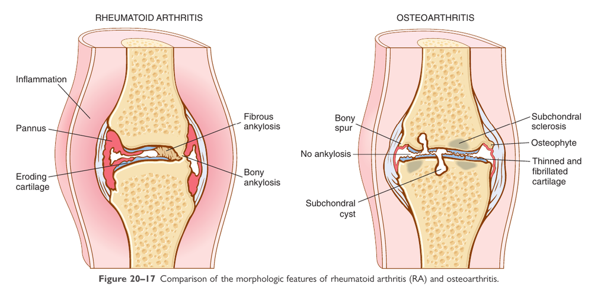

2. Knee OA is more common in Asians  
3. OA may flare *after menopause*.  
6. Genetics : some inherited forms of OA produce OA as early as adolescence. OA in general is thought to have a *strong hereditary component*.  
9. Systemic diseases: [[Genetics Notes#Haemochromatosis|Haemochromatosis]], Acromegaly, *Sickle cell disease*, recurrent *haemarthrosis in haemophilia*.

1. Nodal
2. Hip
3. Knee
- Initially soft tissue swelling with signs of inflammation.
- Several joints will be affected sequentially.
- Over years, inflammation settles leaving behind bony nodules on the posterolateral aspect of **interphalangeal joints.**
- DIP more frequently involved than PIP.
- Familial
- Typical pattern of polyarticular involvement of the **hand joints.**
- **Female predomimance**, develops around menopause.
- Associated with nodal generalized OA (i.e knee, hip, spine OA)
- Limited functional impairement.
- Fixed adduction of the thumb (squared hand) can occur with OA of the thumb.

### Primary generalized OA

Associated with **nodal generalized oa**.  
Sudden onset and severe.  
Also affects hips, knee, first MTP and intervertebral joints.

- Radiological OA may not be symptomatic and may not progress.
- X ray doesn't show changes until late stage
- MRI can show early cartilage changes.
- Arthroscopy can show fissuring of the cartilage
- Synovial fluid is viscous with leukocytes.

## Rheumatoid arthritis Vs. Osteoarthritis

Distinction is important because OA management is 'palliative' while RA management is 'disease modifying'. [Source](https://orthopaedia.com/page/Contrast-osteoarthritis-with-rheumatoid-arthritis)<- seems reliable.

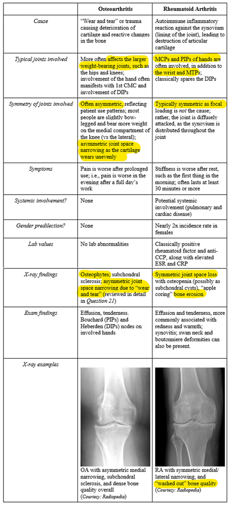

Also, in OA joints don't appear inflamed on examination; but in RA, joints are warm, soft and boggy.

> - Also ?necator americanis, ?ankylstoma duodenale

Spinal cord terminates at **L1/L2.**

?can be used with ordinal variables;

- Liver: histology is unreliable, need to quantitatively measure copper content;
- Histologic demonstration of copper requires rhodanine stain;
- Acute / chronic hepatitis -> The presentation in *children*.

## Non alcoholic fatty liver disease (NASH)

## Morphology of cirrhosis

[Source](https://www.meddean.luc.edu/lumen/meded/orfpath/cirhosis.htm)

- Macronodular cirrhosis - usually viral agents; Causes are Hepatitis B, C, alpha-1-antitrypsin deficiency and **Wilsons**'s disease.[Source](https://webpath.med.utah.edu/LIVEHTML/LIVER009.html)
- Micronodular cirrhosis - < 3mm : caused by chemical agents which distribute uniformly throughout the liver. (eg Alcohol, NASH)
  - alcohol, *hemochromatosis*, *cholestatic causes of cirrhosis*, and *hepatic venous outflow obstruction* are though to cause micronodular cirrhosis and ?wilsons.
- Macro / micro nature of wilson's and haemochromatosis is unclear.